# hw10

K Iwasaki

July 19, 2017

## Measurement error increase or decrease slope coefficent?

Use bwght.RData provided for the next quesiton. Slope coefficient doesn’t change by adding measurement error to the model as below.

```r
model = lm(bwght ~ cigs, data)
x <- data.frame(cigs = data$cigs)
data$error = predict(model, x) - data$bwght

model.error = lm(bwght ~ cigs + error, data)

model.error$coefficients[2] - model$coefficients[2]
```

```
##          cigs
## -1.110223e-14
```

## Examine the relationship between cigarette smoking and a child’s birthweight

## 1. Examine the dependent variable, infant birth weight in ounces (bwght) and the independent variable, the number of cigarettes smoked by the mother each day during pregnacy (cigs).

cigs has skewed distribution to the right with most of mothers don’t smoke. bwdght has alsmot normal distribribution.

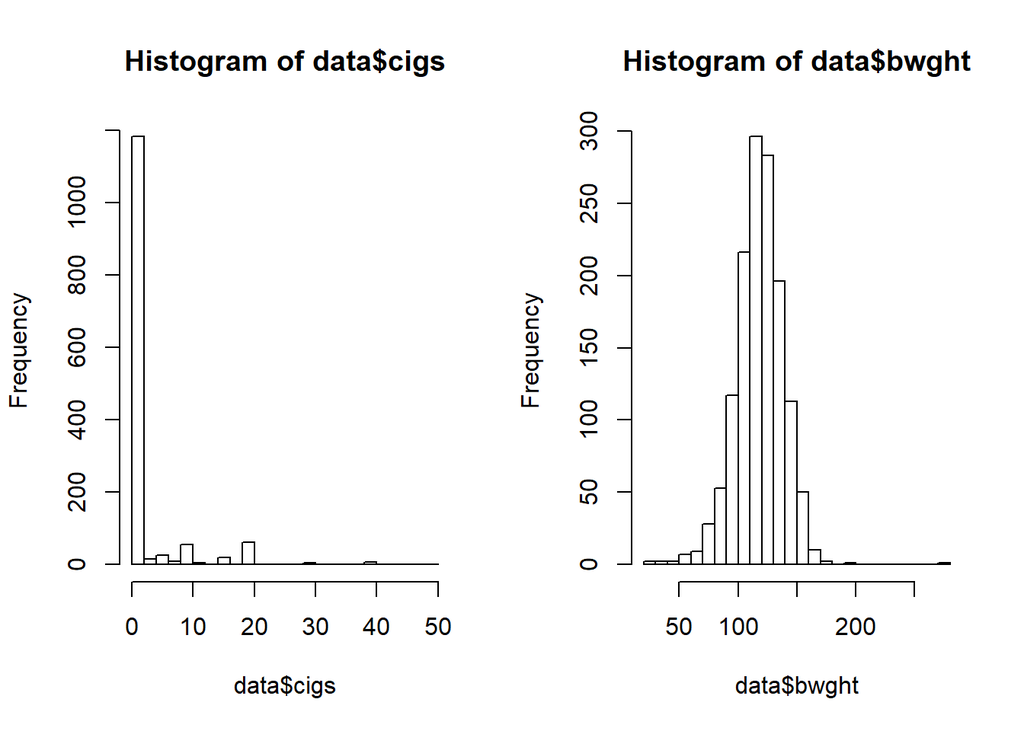

```r
par(mfrow=c(1,2))
hist(data$cigs, breaks = 30)
hist(data$bwght, breaks = 30)
```

```r
summary(data$cigs)
```

```
##    Min. 1st Qu.  Median    Mean 3rd Qu.    Max.
##   0.000   0.000   0.000   2.087   0.000  50.000
```

```r
summary(data$bwght)
```

```
##    Min. 1st Qu.  Median    Mean 3rd Qu.    Max.
##    23.0   107.0   120.0   118.7   132.0   271.0
```

## 2. Fit a linear model that predicts bwght as a function of cigs. Superimpose your regression line on a scatterplot of your variables.

```r
model = lm(bwght ~ cigs, data)
model
```

```
##
## Call:
## lm(formula = bwght ~ cigs, data = data)
##
## Coefficients:
## (Intercept)         cigs
##    119.7719      -0.5138
```

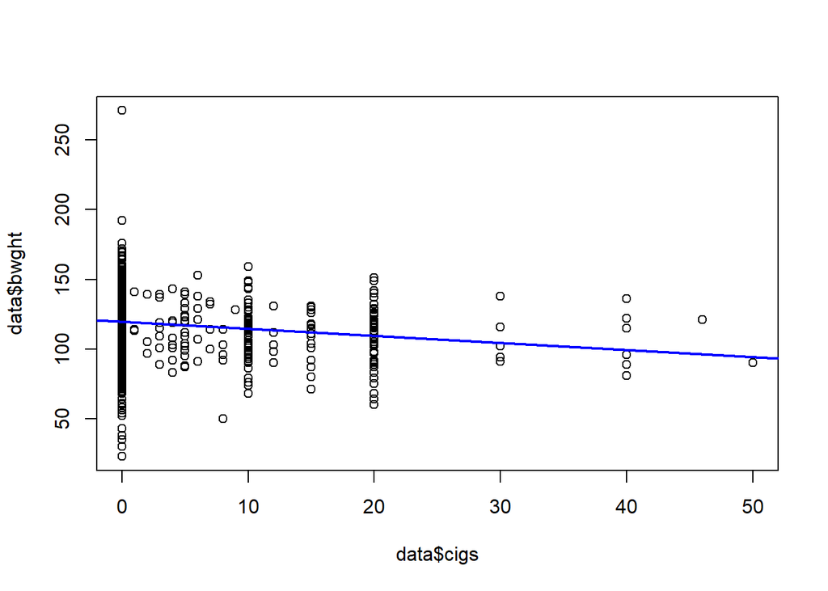

```r
plot(x=data$cigs, y = data$bwght)
abline(model,col="blue",lwd=2)
```